# Practica2_Morfologia_Medica

**Visión por Computador — Práctica 2: Operaciones Morfológicas en Imágenes Médicas**

Docente: Vladimir Robles Bykbaev | Período: Abril – Agosto 2026  
Integrantes: Paúl Sebastián Naspud, Jennyfer Camila Ramírez | Junio 2026

> Referencia: Hassanpour, H., Samadiani, N. & Salehi, S.M.M. (2015). *Using morphological transforms to enhance the contrast of medical images.* Egyptian Journal of Radiology and Nuclear Medicine, 46(2), 481–489.

```python
import numpy as np
import cv2
import matplotlib.pyplot as plt
import os
import warnings

warnings.filterwarnings('ignore')
plt.rcParams.update({'figure.dpi': 110, 'axes.titlesize': 10, 'axes.titleweight': 'bold'})

IMAGES_DIR = 'imagenes'
KERNEL_SIZES = [7, 19, 37]  # Tamaños sugeridos en la literatura médica (hasta 37×37)

print('OpenCV:', cv2.__version__)
print('Tamaños de kernel a probar:', KERNEL_SIZES)
```

```
OpenCV: 4.14.0-pre
Tamaños de kernel a probar: [7, 19, 37]
```

## 1. Imágenes Médicas Seleccionadas

Se usa el dataset **MedMNIST** (Yang et al., 2023) — colección estandarizada de imágenes médicas reales, libre y sin registro. Se descargan 3 subconjuntos con modalidades distintas:

- **PneumoniaMNIST** — Radiografías de tórax (normal / neumonía), 5,856 imágenes, 20.6 MB
- **RetinaMNIST** — Angiografías de fondo de ojo, 1,600 imágenes, 13.2 MB
- **OrganCMNIST** — Tomografías abdominales (corte coronal), 25,221 imágenes, 80.3 MB

Instalación requerida (una sola vez):

```
pip install medmnist
```

> Yang, J. et al. (2023). MedMNIST v2. *Scientific Data*, 10, 409.

```python
import numpy as np
import os

MEDMNIST_DIR = 'medmnist_data'

# Los NPZ se descargan una sola vez (~114 MB total). Si no están, ejecuta en terminal:
#   python descargar_medmnist.py
for f in ['pneumoniamnist_64.npz', 'organcmnist_64.npz', 'retinamnist_64.npz']:
    path = os.path.join(MEDMNIST_DIR, f)
    if not os.path.exists(path):
        raise FileNotFoundError(
            f"Falta {f} en {MEDMNIST_DIR}/\n"
            "Ejecuta: python descargar_medmnist.py"
        )

def load_from_npz(npz_path, idx=0, out_size=512):
    """Carga una imagen del NPZ MedMNIST, convierte a uint8 gris y redimensiona."""
    data = np.load(npz_path)
    imgs = data['train_images']   # shape: (N, 64, 64) o (N, 64, 64, 3)
    img = imgs[idx]
    if img.ndim == 3:             # RGB → gris
        img = np.mean(img, axis=2).astype(np.uint8)
    return cv2.resize(img.astype(np.uint8), (out_size, out_size), interpolation=cv2.INTER_CUBIC)

img1 = load_from_npz(f'{MEDMNIST_DIR}/pneumoniamnist_64.npz', idx=10)  # radiografía
img2 = load_from_npz(f'{MEDMNIST_DIR}/organcmnist_64.npz',   idx=50)  # tomografía
img3 = load_from_npz(f'{MEDMNIST_DIR}/retinamnist_64.npz',   idx=5)   # angiografía

IMAGES = [
    (img1, 'Radiografía de Tórax (PneumoniaMNIST)'),
    (img2, 'Tomografía Abdominal (OrganCMNIST)'),
    (img3, 'Angiografía de Retina (RetinaMNIST)'),
]

print('Imágenes cargadas:')
for img, name in IMAGES:
    print(f'  {name}: shape={img.shape}, rango=[{img.min()}, {img.max()}]')
```

```
Imágenes cargadas:
  Radiografía de Tórax (PneumoniaMNIST): shape=(512, 512), rango=[11, 221]
  Tomografía Abdominal (OrganCMNIST): shape=(512, 512), rango=[0, 255]
  Angiografía de Retina (RetinaMNIST): shape=(512, 512), rango=[0, 206]
```

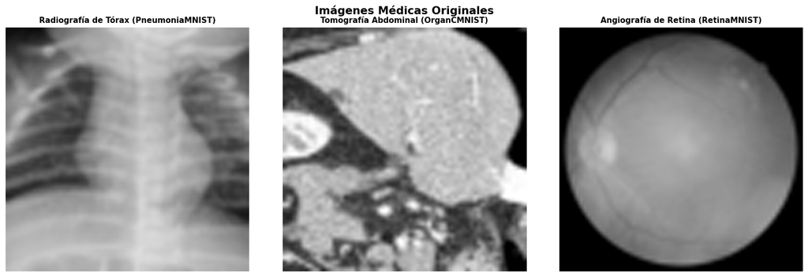

```python
# ─── Visualización de imágenes originales ────────────────────────────────────
fig, axes = plt.subplots(1, 3, figsize=(15, 5))
fig.suptitle('Imágenes Médicas Originales', fontsize=14, fontweight='bold')

for ax, (img, name) in zip(axes, IMAGES):
    ax.imshow(img, cmap='gray', vmin=0, vmax=255)
    ax.set_title(name)
    ax.axis('off')

plt.tight_layout()
plt.savefig(f'{IMAGES_DIR}/00_originales.png', bbox_inches='tight')
plt.show()
```

```python
# ─── Funciones auxiliares ─────────────────────────────────────────────────────

def get_kernel(size):
    """Retorna kernel elíptico (más adecuado para estructuras anatómicas redondeadas)."""
    return cv2.getStructuringElement(cv2.MORPH_ELLIPSE, (size, size))


def apply_morphology(img, kernel_sizes):
    """Aplica las 4 operaciones morfológicas con distintos tamaños de kernel."""
    results = {}
    ops = {
        'Erosión':    lambda i, k: cv2.erode(i, k),
        'Dilatación': lambda i, k: cv2.dilate(i, k),
        'Top Hat':    lambda i, k: cv2.morphologyEx(i, cv2.MORPH_TOPHAT, k),
        'Black Hat':  lambda i, k: cv2.morphologyEx(i, cv2.MORPH_BLACKHAT, k),
    }
    for op_name, op_fn in ops.items():
        results[op_name] = {}
        for ks in kernel_sizes:
            k = get_kernel(ks)
            results[op_name][ks] = op_fn(img, k)
    return results


def plot_operation(image, img_name, op_name, results_by_size, kernel_sizes, cmap='gray'):
    """Comparativa: Original vs 3 tamaños de kernel para una operación."""
    n = len(kernel_sizes)
    fig, axes = plt.subplots(1, n + 1, figsize=(5 * (n + 1), 5))
    fig.suptitle(f'{op_name} — {img_name}', fontsize=13, fontweight='bold')

    axes[0].imshow(image, cmap=cmap, vmin=0, vmax=255)
    axes[0].set_title('Original')
    axes[0].axis('off')

    for ax, ks in zip(axes[1:], kernel_sizes):
        ax.imshow(results_by_size[ks], cmap=cmap, vmin=0, vmax=255)
        ax.set_title(f'Kernel {ks}×{ks}')
        ax.axis('off')

    plt.tight_layout()
    plt.show()


# Precalcular todas las operaciones para las 3 imágenes
all_results = []
for img, name in IMAGES:
    res = apply_morphology(img, KERNEL_SIZES)
    all_results.append((img, name, res))

print('Operaciones morfológicas calculadas para las 3 imágenes.')
```

```
Operaciones morfológicas calculadas para las 3 imágenes.
```

## 2. Erosión

Aplica el mínimo local dentro del kernel. Adelgaza estructuras brillantes (huesos, calcificaciones) y elimina ruido puntual. A mayor tamaño de kernel, mayor pérdida de detalle fino.

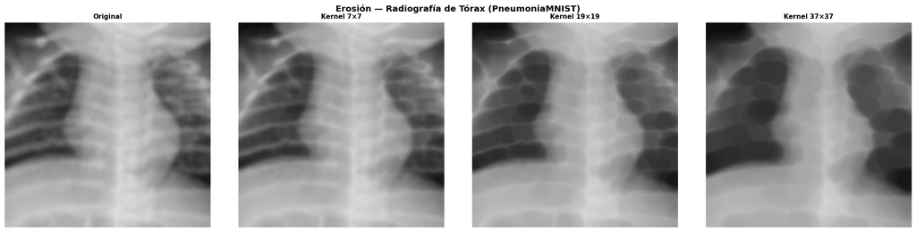

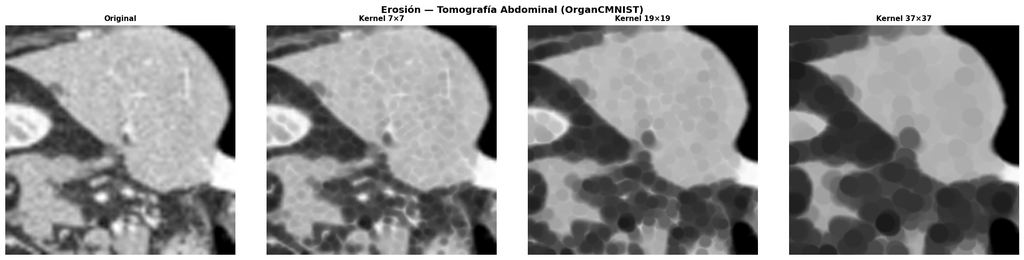

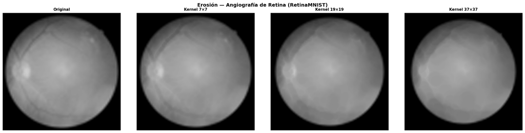

```python
for img, name, res in all_results:
    plot_operation(img, name, 'Erosión', res['Erosión'], KERNEL_SIZES)
```

## 3. Dilatación

Aplica el máximo local. Engrosa estructuras brillantes y rellena pequeños huecos oscuros. Kernels grandes pueden fusionar estructuras adyacentes y saturar regiones claras.

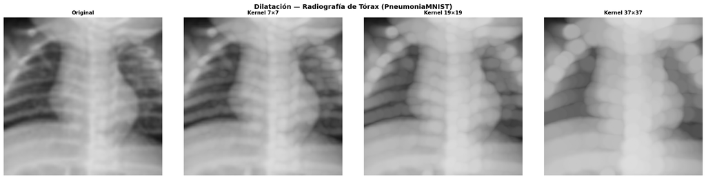

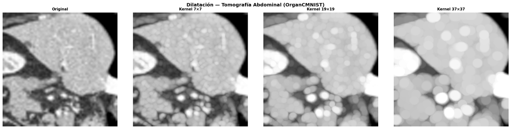

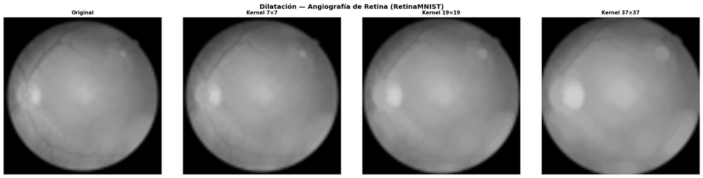

```python
for img, name, res in all_results:
    plot_operation(img, name, 'Dilatación', res['Dilatación'], KERNEL_SIZES)
```

## 4. Top Hat

Extrae las estructuras brillantes más pequeñas que el kernel (diferencia entre imagen original y su apertura morfológica). El resultado muestra detalles finos brillantes sobre fondo casi negro: útil para detectar calcificaciones, vasos delgados o micronódulos.

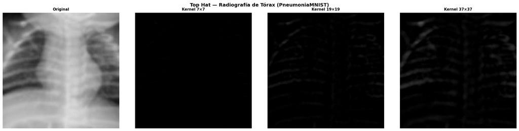

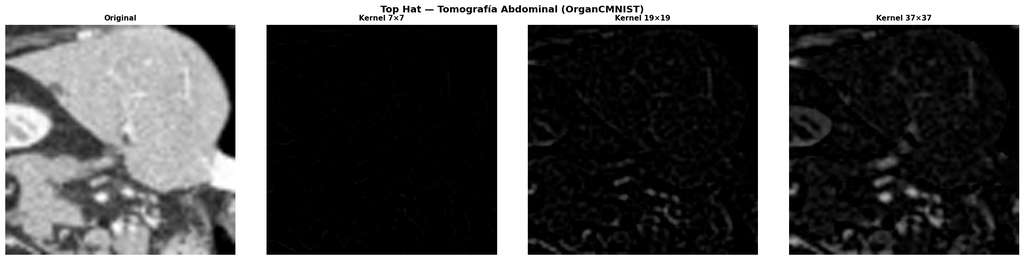

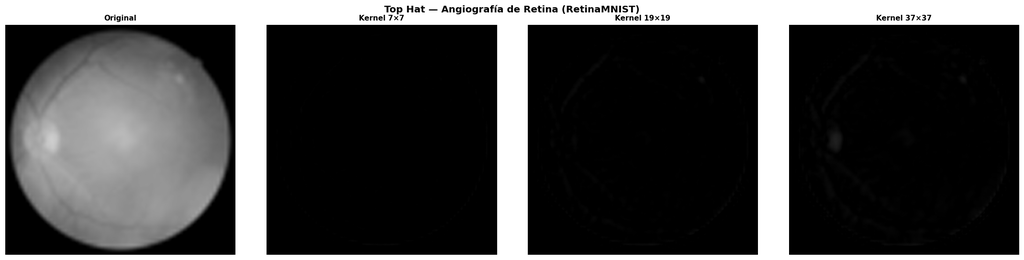

```python
for img, name, res in all_results:
    plot_operation(img, name, 'Top Hat', res['Top Hat'], KERNEL_SIZES)
```

## 5. Black Hat

Extrae las estructuras oscuras más pequeñas que el kernel (diferencia entre cierre morfológico e imagen original). Complementa al Top Hat: resalta vasos oscuros en angiografías, surcos cerebrales en CT y sombras intercostales en radiografías.

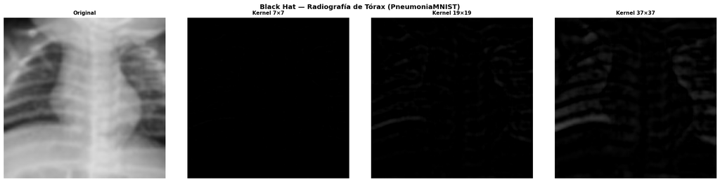

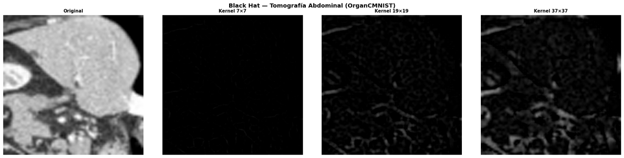

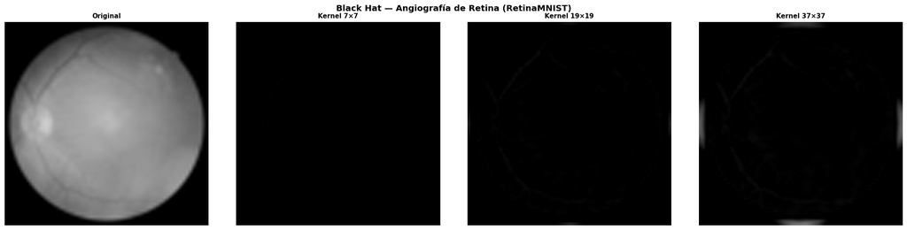

```python
for img, name, res in all_results:
    plot_operation(img, name, 'Black Hat', res['Black Hat'], KERNEL_SIZES)
```

## 6. Fórmula de Mejora: Original + (Top Hat − Black Hat)

La fórmula propuesta por Hassanpour et al. (2015) combina ambas operaciones para mejorar el contraste sin deformar la anatomía global:

$$f_{\text{mejorada}} = \text{clip}\,(f + TH - BH,\; 0,\; 255)$$

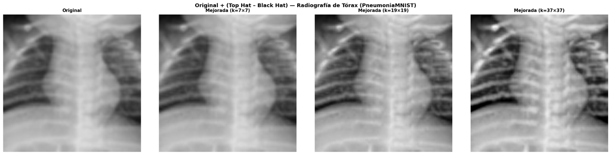

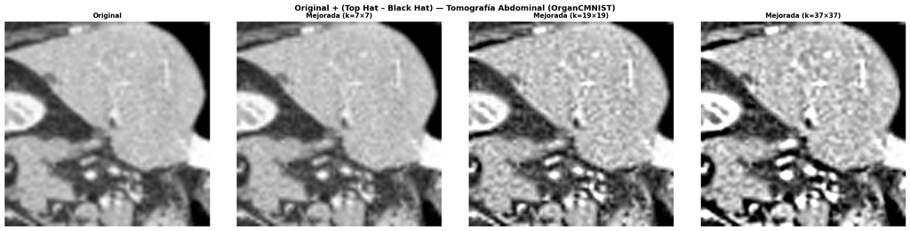

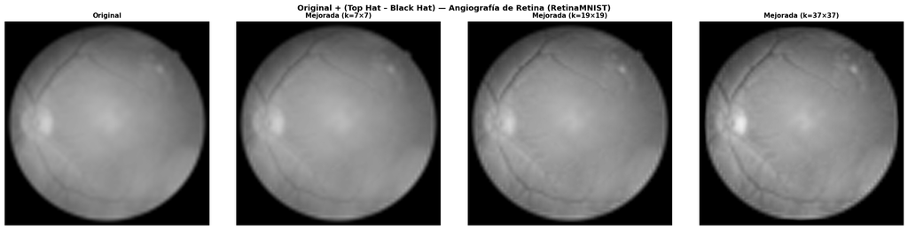

```python
def enhance_contrast(img, kernel_size):
    """Aplica f + TopHat - BlackHat con saturación a [0, 255]."""
    k = get_kernel(kernel_size)
    top_hat  = cv2.morphologyEx(img, cv2.MORPH_TOPHAT,   k)
    black_hat = cv2.morphologyEx(img, cv2.MORPH_BLACKHAT, k)
    # Operar en int16 para evitar desbordamiento en uint8
    enhanced = img.astype(np.int16) + top_hat.astype(np.int16) - black_hat.astype(np.int16)
    return np.clip(enhanced, 0, 255).astype(np.uint8)


for img, name, res in all_results:
    fig, axes = plt.subplots(1, len(KERNEL_SIZES) + 1, figsize=(5 * (len(KERNEL_SIZES) + 1), 5))
    fig.suptitle(f'Original + (Top Hat – Black Hat) — {name}', fontsize=12, fontweight='bold')

    axes[0].imshow(img, cmap='gray', vmin=0, vmax=255)
    axes[0].set_title('Original')
    axes[0].axis('off')

    for ax, ks in zip(axes[1:], KERNEL_SIZES):
        enhanced = enhance_contrast(img, ks)
        ax.imshow(enhanced, cmap='gray', vmin=0, vmax=255)
        ax.set_title(f'Mejorada (k={ks}×{ks})')
        ax.axis('off')

    plt.tight_layout()
    plt.savefig(f'{IMAGES_DIR}/formula_mejora_{name.split()[0].lower()}.png', bbox_inches='tight')
    plt.show()
```

## 7. Comparativa Final (kernel 37×37)

Panel completo con todas las operaciones usando el kernel de mayor tamaño, como en las Ilustraciones 4 y 5 de Hassanpour et al. (2015).

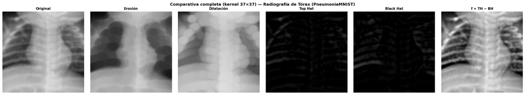

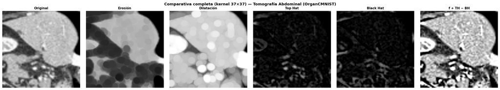

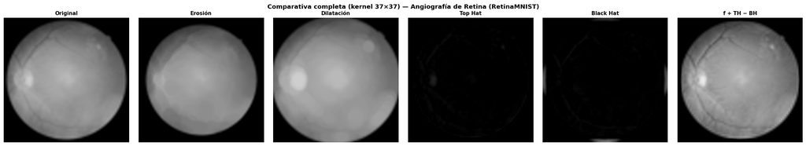

```python
KS_FINAL = 37
k_final = get_kernel(KS_FINAL)

OP_LABELS = ['Original', 'Erosión', 'Dilatación', 'Top Hat', 'Black Hat', 'f + TH − BH']

for img, name, res in all_results:
    enhanced = enhance_contrast(img, KS_FINAL)
    images_row = [
        img,
        res['Erosión'][KS_FINAL],
        res['Dilatación'][KS_FINAL],
        res['Top Hat'][KS_FINAL],
        res['Black Hat'][KS_FINAL],
        enhanced,
    ]

    fig, axes = plt.subplots(1, 6, figsize=(22, 4))
    fig.suptitle(f'Comparativa completa (kernel 37×37) — {name}', fontsize=12, fontweight='bold')

    for ax, im, lbl in zip(axes, images_row, OP_LABELS):
        ax.imshow(im, cmap='gray', vmin=0, vmax=255)
        ax.set_title(lbl)
        ax.axis('off')

    plt.tight_layout()
    plt.savefig(f'{IMAGES_DIR}/comparativa_final_{name.split()[0].lower()}.png', bbox_inches='tight')
    plt.show()
```

## 8. Reflexiones y Análisis

**Comparativa de nitidez: imagen original vs. imagen con operaciones morfológicas**

Las operaciones individuales degradan la imagen de formas opuestas: la erosión oscurece y reduce estructuras, la dilatación las infla y une. El Top Hat y el Black Hat por separado solo muestran partes del contenido (detalles brillantes u oscuros), lo que los hace útiles para segmentación pero no como reemplazo de la imagen original.

En los tres casos la fórmula mejora la posibilidad de observar estructuras patológicas o anatómicas de interés frente a la imagen original, confirmando los resultados reportados por Hassanpour et al. (2015).